# Stroop Effect WGU

Josh Folsom

6/26/2021

### Data Exploration of Stroop Effect and Congruency

#### This report explores a small dataset in order to answer 5 questions, which you can move to using the Table of Contents to the left.

#### I will use a combination of written explanations and statistical analyses in order to provide my answers.

### Introducing the Dataset

#### From the provided ‘Background Information’

##### In a Stroop task, participants are presented with a list of words, with each word displayed in a color of ink. The participant’s task is to say out loud the color of the ink in which the word is printed. The task has two conditions: a congruent words condition, and an incongruent words condition. In the congruent words condition, the words being displayed are color words whose names match the colors in which they are printed: for example RED, BLUE. In the incongruent words condition, the words displayed are color words whose names do not match the colors in which they are printed: for example PURPLE, ORANGE. In each case, we measure the time it takes to name the ink colors in equally-sized lists. Each participant will go through and record a time from each condition.

### 1. What is our independent variable? What is our dependent variable?

##### The independant variable: The Congruent/Incongruent condition; Whether a words color and text match.

##### The dependant variable: The time it takes for each participant to name the ink colors in equally-sized lists.

### 2. What is an appropriate set of hypotheses for this task? What kind of statistical test do you expect to perform? Justify your choices.

##### The Null Hypothesis for this dataset is that congruency will have no measurable effect on speed of processing.

#### H0: μ == μi

##### The Alternative Hypothesis is that there will be a measurable difference in speed of analysis. wherin

#### HA: μ != μi

##### I’ll be using a t-test for this, based on the uncertainty of the full population for this dataset, and the ability to check the results of the participant under both conditions.

##### The t test will need to be 2 tailed, because we’re not absolutely certain that the congruency will (potentially) effect data in a specific desired direction. The type of t test is a paired dependent test with two conditions: the control of congruent words with the variable of incongruent words

#### some assumptions on our sample of 24 participants are:

##### The data is normally distributed

##### The data has a linear relationship

##### This sample, or any other we used from the dataset would have the same variance.

### 3. Report some descriptive statistics regarding this dataset. Include at least one measure of central tendency and at least one measure of variability.

##### Sample size: 24

```
##        ID          Congruent      Incongruent
##  Min.   : 1.00   Min.   : 8.63   Min.   :15.69
##  1st Qu.: 6.75   1st Qu.:11.90   1st Qu.:18.72
##  Median :12.50   Median :14.36   Median :21.02
##  Mean   :12.50   Mean   :14.05   Mean   :22.02
##  3rd Qu.:18.25   3rd Qu.:16.20   3rd Qu.:24.05
##  Max.   :24.00   Max.   :22.33   Max.   :35.26
```

#### Standard Deviations of Congruent, and Incongruent columns

```
## [1] 3.559358
```

```
## [1] 4.797057
```

#### Degrees of Freedom

```
## [1] 23
```

### 4. Provide one or two visualizations that show the distribution of the sample data. Write one or two sentences noting what you observe about the plot or plots.

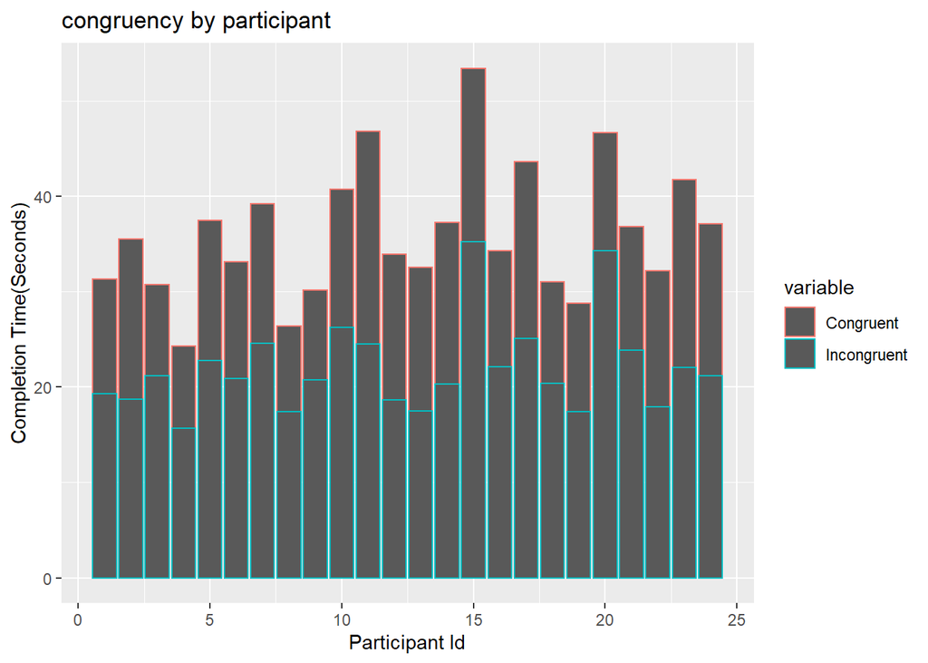

##### This Graph shows a unfailing pattern of participants incongruent analysis speeds being lower than their congruent speeds.

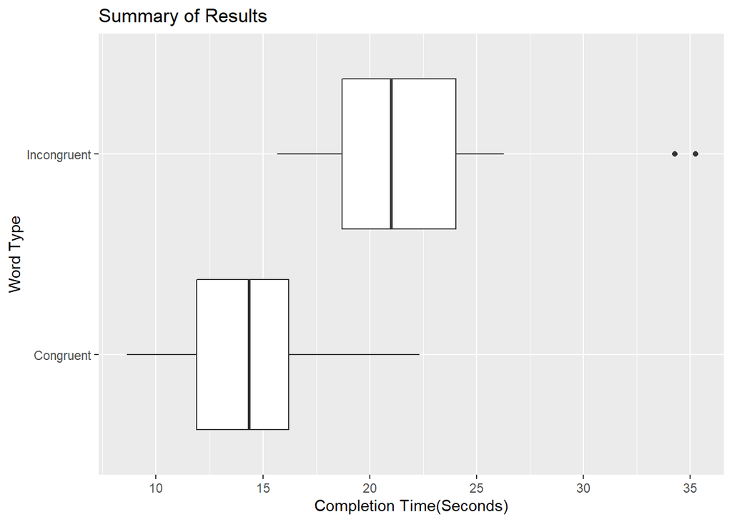

##### The second graph reinforces the first graph’s data, and shows that there is also a tighter range for completion times in the congruent tests. It appears there are two (seeming)outliers in the incongruent dataset, which represents 2 participants that had an especially hard time with that type of analysis.

```
##    ID    variable  value
## 39 15 Incongruent 35.255
## 44 20 Incongruent 34.288
## 34 10 Incongruent 26.282
## 41 17 Incongruent 25.139
## 31  7 Incongruent 24.572
```

##### And this ordered summary shows the two outliers.

### 5. Now, perform the statistical test and report your results. What is your confidence level and your critical statistic value? Do you reject the null hypothesis or fail to reject it? Come to a conclusion in terms of the experiment task. Did the results match up with your expectations?

##### I’m performing with a confidence level of 95%

```
## [1] -8.020707
```

##### Above is the final t_statistic, rounded to the thousandths at -8.021. This shows a significant deviation, and is statistically significant compared to the critical statistic value, This means we can reject the null hypothesis.

##### Our Probability under the t-distribution table at the crossing of 8.020 and 23(dof) was .0000

##### our Confidence Interval bounds were:

```
## [1] -9.958877
```

```
## [1] -5.859655
```

##### These bounds should cover our data with a 95% confidence rate

###6. Optional: What do you think is responsible for the effects observed? Can you think of an alternative or similar task that would result in a similar effect? Some research about the problem will be helpful for thinking about these two questions!

##### I think that since we are having to override a conditioned response when the text and color don’t match that it is perfectly reasonable that it would take longer for participants to correctly analyze incongruent words. I would like to see this style of test performed on another interesting word related experiment, wherein, within a paragraph all letters in a word, save the first and the last, are shuffled, and the participants are told to read the sentences.